# Презентация по лабораторной работе 4

## 6. Оптимизация

Я запустила его, и все заработало. Оптимальными параметрами, которые сводят к минимуму смертность при сохранении пиковой заболеваемости ниже 30%, являются: $\beta$ = 0,122 (низкая инфекционность, $R_0$ ≈ 1,7), время выявления = 7 дней и уровень смертности = 1,04%. При таких параметрах пик эпидемии остается ниже 30%, а смертность приближается к 0%.(рис.30)

## 6. Оптимизация

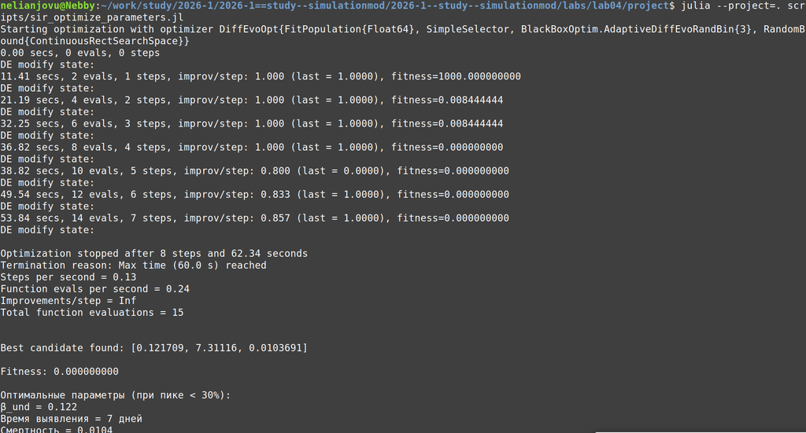

Рисунок 32: оптимизация параметров

## 6. Оптимизация

После этого я создала текст на основе литературного кода: чистого кода, записной книжки jupyter и документации в формате Quarto. Я запускала все ячейки в файле jupyter notebook, и все работает хорошо(рис.31)

[figure not shown]

Рисунок 33: создание файлов

## Результаты

Я создала файл sir_visualize_dynamics.jl и копирую в него скрипт из лабораторного руководства. Этот скрипт загружает результаты параметрического сканирования и строит единый составной график, объединяющий три панели: пик эпидемии и конечная доля инфицированных; число умерших; доля выздоровевших.(рис.32)

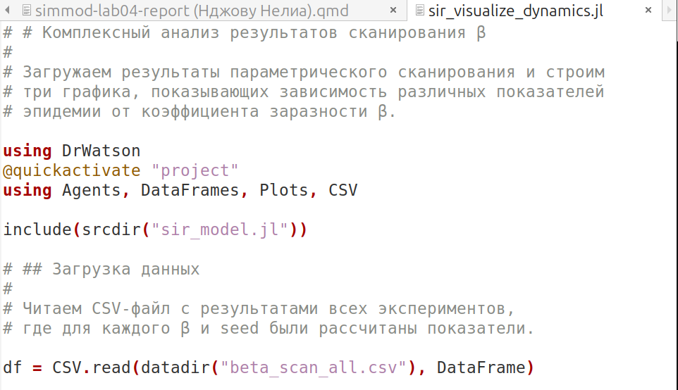

Рисунок 34: визуализация результатов

## Результаты

Я запустила его, и все заработало, я получила график ниже. График пиковой инфицированности в сравнении с $\beta$ показывает, сколько людей заболевает в самый неподходящий момент. График смертности в сравнении с $\beta$ показывает, сколько людей умирает. График окончательного выздоровления в сравнении с $\beta$ показывает, сколько людей выживают и приобретают иммунитет(рис.33)

## Результаты

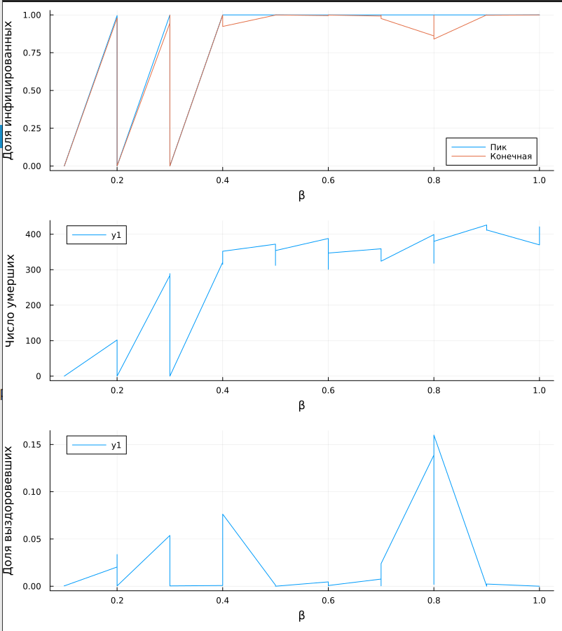

Рисунок 35: График

## Результаты

После этого я создала текст на основе литературного кода: чистого кода, записной книжки jupyter и документации в формате Quarto. Я запускала все ячейки в файле jupyter notebook, и все работает хорошо(рис.34)

[figure not shown]

Рисунок 36: создание файлов

## Выводы

Выполнив эту лабораторную работу, я использовала агентную модель для моделирования SIR модель.Я провла несколько экспериментов, изменив параметры и окружающую среду